# Part I - (PISA Data Exploration)

## by Emmie Alaka

- Introduction
- Preliminary Wrangling
- Univariate Exploration
- Bivariate Exploration
- Multivariate Exploration
- Conclusions

## Introduction

**PISA** is a survey of students' skills and knowledge as they approach the end of compulsory education. This survey examines;

- how well students have learned the school curriculum,
- how well prepared they are for life beyond school.

Around *510,000* students in *65 economies* took part in the PISA 2012 assessment of **reading, mathematics and science**. Of those economies, *44* took part in an assessment of *creative problem solving* and *18* in an assessment of *financial literacy*.

To start us off, we need to upload these Libraries;

- Numpy
- Pandas
- Matplotlib
- Seaborn
- Zipfile
- Patches

## Preliminary Wrangling

```python
# import all packages and set plots to be embedded inline
import numpy as np
import pandas as pd
import dask.dataframe as dd
import os
from tqdm import tqdm
import matplotlib.pyplot as plt
from matplotlib.pyplot import *
import seaborn as sb
%matplotlib inline
import zipfile
import csv as csv
import matplotlib.patches as mpatches
```

```python
# Extract all contents from zip file
with zipfile.ZipFile('pisa2012.csv.zip', 'r') as myzip:
    myzip.extractall()
```

```python
# Read the pisa2012.csv file which is large with over 485492 rows and 636 columns
pisa2012='pisa2012.csv'
import subprocess

def file_len(pisa2012):
    p = subprocess.Popen(['wc', '-l', pisa2012], stdout=subprocess.PIPE,
                                              stderr=subprocess.PIPE)
    result, err = p.communicate()
    if p.returncode != 0:
        raise IOError(err)
    return int(result.strip().split()[0])+1

n_rows = file_len(pisa2012)
print (f'Exact number of rows: {n_rows}')
```

```
Exact number of rows: 485492
```

```python
# Read only 20 rows of the dataset
df = pd.read_csv('pisa2012.csv', nrows=20)
df.head()
```

|  | Unnamed: 0 | CNT | SUBNATIO | STRATUM | OECD | NC | SCHOOLID | STIDSTD | ST01Q01 | ST02Q01 | ... | W_FSTR75 | W_FSTR76 | W_FSTR77 | W_FSTR78 | W_FSTR79 | W_FSTR80 | WVARSTRR | VAR_UNIT | SENWGT_STU | VER_STU |
| --- | --- | --- | --- | --- | --- | --- | --- | --- | --- | --- | --- | --- | --- | --- | --- | --- | --- | --- | --- | --- | --- |
| 0 | 1 | Albania | 80000 | ALB0006 | Non-OECD | Albania | 1 | 1 | 10 | 1 | ... | 13.7954 | 13.9235 | 13.1249 | 13.1249 | 4.3389 | 13.0829 | 19 | 1 | 0.2098 | 22NOV13 |
| 1 | 2 | Albania | 80000 | ALB0006 | Non-OECD | Albania | 1 | 2 | 10 | 1 | ... | 13.7954 | 13.9235 | 13.1249 | 13.1249 | 4.3389 | 13.0829 | 19 | 1 | 0.2098 | 22NOV13 |
| 2 | 3 | Albania | 80000 | ALB0006 | Non-OECD | Albania | 1 | 3 | 9 | 1 | ... | 12.7307 | 12.7307 | 12.7307 | 12.7307 | 4.2436 | 12.7307 | 19 | 1 | 0.1999 | 22NOV13 |
| 3 | 4 | Albania | 80000 | ALB0006 | Non-OECD | Albania | 1 | 4 | 9 | 1 | ... | 12.7307 | 12.7307 | 12.7307 | 12.7307 | 4.2436 | 12.7307 | 19 | 1 | 0.1999 | 22NOV13 |
| 4 | 5 | Albania | 80000 | ALB0006 | Non-OECD | Albania | 1 | 5 | 9 | 1 | ... | 12.7307 | 12.7307 | 12.7307 | 12.7307 | 4.2436 | 12.7307 | 19 | 1 | 0.1999 | 22NOV13 |

5 rows × 636 columns

```python
#set columns to most suitable type to optimize for memory usage
pisatypes = { 'CNT': 'str',
              'STIDSTD': 'str',
              'ST04Q01': 'str',
              'ST11Q01': 'str',
              'ST11Q02': 'str',
              'ST26Q04': 'str',
              'ST27Q03': 'str',
              'ST87Q03': 'str',
              'AGE': 'float32',
              'HOMEPOS': 'float32',
              'ICTRES': 'float32',
              'ICTSCH': 'float32',
              'IMMIG': 'str',
              'WEALTH': 'float32',
              'PV1MATH': 'float32',
             'PV2MATH': 'float32',
             'PV3MATH': 'float32',
             'PV4MATH': 'float32',
             'PV5MATH': 'float32',
              'PV1READ': 'float32',
             'PV2READ': 'float32',
             'PV3READ': 'float32',
             'PV4READ': 'float32',
             'PV5READ': 'float32',
              'PV1SCIE': 'float32',
             'PV2SCIE': 'float32',
             'PV3SCIE': 'float32',
             'PV4SCIE': 'float32',
             'PV5SCIE': 'float32'
            }

cols = list(pisatypes.keys())
```

```python
# The approximate number of rows in the dataset
chunksize = 500_000
```

```python
# Append the chunk to list and merge all
df_list = []
for df in tqdm(pd.read_csv(pisa2012, usecols=cols, dtype=pisatypes, chunksize=chunksize)):
    df_list.append(df)
df_list
```

```
1it [00:26, 26.58s/it]
```

[output not shown]

[output cut: 238 more lines]

```python
# Merge all dataframes into one dataframe
df = pd.concat(df_list)

# Delete the dataframe list to release memory
del df_list

# See what we have loaded
df.info()
```

```
<class 'pandas.core.frame.DataFrame'>
RangeIndex: 485490 entries, 0 to 485489
Data columns (total 29 columns):
CNT        485490 non-null object
STIDSTD    485490 non-null object
ST04Q01    485490 non-null object
ST11Q01    460559 non-null object
ST11Q02    441036 non-null object
ST26Q04    473877 non-null object
ST27Q03    473459 non-null object
ST87Q03    310821 non-null object
AGE        485374 non-null float32
HOMEPOS    479807 non-null float32
ICTRES     477754 non-null float32
ICTSCH     297995 non-null float32
IMMIG      471793 non-null object
WEALTH     479597 non-null float32
PV1MATH    485490 non-null float32
PV2MATH    485490 non-null float32
PV3MATH    485490 non-null float32
PV4MATH    485490 non-null float32
PV5MATH    485490 non-null float32
PV1READ    485490 non-null float32
PV2READ    485490 non-null float32
PV3READ    485490 non-null float32
PV4READ    485490 non-null float32
PV5READ    485490 non-null float32
PV1SCIE    485490 non-null float32
PV2SCIE    485490 non-null float32
PV3SCIE    485490 non-null float32
PV4SCIE    485490 non-null float32
PV5SCIE    485490 non-null float32
dtypes: float32(20), object(9)
memory usage: 70.4+ MB
```

```python
# Display both the head and tail of the dataframe
display(df.head())
display(df.tail())
```

|  | CNT | STIDSTD | ST04Q01 | ST11Q01 | ST11Q02 | ST26Q04 | ST27Q03 | ST87Q03 | AGE | HOMEPOS | ... | PV1READ | PV2READ | PV3READ | PV4READ | PV5READ | PV1SCIE | PV2SCIE | PV3SCIE | PV4SCIE | PV5SCIE |
| --- | --- | --- | --- | --- | --- | --- | --- | --- | --- | --- | --- | --- | --- | --- | --- | --- | --- | --- | --- | --- | --- |
| 0 | Albania | 00001 | Female | Yes | Yes | No | None | Strongly disagree | 16.17 | -2.61 | ... | 249.576202 | 254.341995 | 406.849609 | 175.705307 | 218.598099 | 341.700897 | 408.839996 | 348.228302 | 367.810486 | 392.987701 |
| 1 | Albania | 00002 | Female | Yes | Yes | Yes | Three or more | NaN | 16.17 | 1.41 | ... | 406.293610 | 349.897491 | 400.733398 | 369.755310 | 396.761810 | 548.992920 | 471.596405 | 471.596405 | 443.621796 | 454.811615 |
| 2 | Albania | 00003 | Female | Yes | Yes | Yes | Two | NaN | 15.58 | 0.14 | ... | 401.209991 | 404.387207 | 387.706696 | 431.393799 | 401.209991 | 499.664307 | 428.795197 | 492.204407 | 512.719116 | 499.664307 |
| 3 | Albania | 00004 | Female | Yes | Yes | Yes | One | NaN | 15.67 | -0.73 | ... | 547.362976 | 481.435303 | 461.577606 | 425.039307 | 471.903595 | 438.679596 | 481.574005 | 448.937012 | 474.114105 | 426.557312 |
| 4 | Albania | 00005 | Female | Yes | Yes | Yes | Two | Strongly agree | 15.50 | -0.57 | ... | 311.770691 | 141.788300 | 293.501495 | 272.849487 | 260.140503 | 361.562805 | 275.773987 | 372.752686 | 403.524811 | 422.174591 |

5 rows × 29 columns

|  | CNT | STIDSTD | ST04Q01 | ST11Q01 | ST11Q02 | ST26Q04 | ST27Q03 | ST87Q03 | AGE | HOMEPOS | ... | PV1READ | PV2READ | PV3READ | PV4READ | PV5READ | PV1SCIE | PV2SCIE | PV3SCIE | PV4SCIE | PV5SCIE |
| --- | --- | --- | --- | --- | --- | --- | --- | --- | --- | --- | --- | --- | --- | --- | --- | --- | --- | --- | --- | --- | --- |
| 485485 | Vietnam | 04955 | Female | Yes | Yes | Yes | One | NaN | 15.83 | -1.81 | ... | 460.227203 | 476.113403 | 472.936188 | 472.141907 | 481.673615 | 559.809814 | 528.105225 | 519.712830 | 535.565125 | 538.362610 |
| 485486 | Vietnam | 04956 | Male | Yes | Yes | Yes | Three or more | NaN | 16.17 | -0.45 | ... | 490.932495 | 479.705292 | 448.429413 | 565.513428 | 451.637207 | 538.735474 | 493.976105 | 493.043610 | 561.115295 | 535.005615 |
| 485487 | Vietnam | 04957 | Male | Yes | Yes | No | None | Agree | 15.83 | -2.19 | ... | 462.623901 | 514.750305 | 434.555786 | 457.812195 | 511.542511 | 536.870605 | 571.372620 | 488.381195 | 548.992920 | 563.912720 |
| 485488 | Vietnam | 04958 | Male | Yes | Yes | Yes | One | Disagree | 15.83 | -1.28 | ... | 505.287292 | 522.128174 | 513.306824 | 528.543701 | 522.930115 | 511.040710 | 532.487915 | 524.095520 | 551.137573 | 514.770630 |
| 485489 | Vietnam | 04959 | Female | Yes | No | NaN | None | NaN | 15.33 | -0.92 | ... | 532.350586 | 483.103394 | 479.926086 | 459.274109 | 488.663513 | 530.622925 | 473.741089 | 477.471100 | 477.471100 | 505.445709 |

5 rows × 29 columns

```python
# Store the dataset to minimize rerunning it everytime you load it
df.to_csv('pisa2012.csv')
```

## Structure of the Pisa dataset

The Pisa Dataset has **485490** students and **636** features that describes each of them.

### Main features of interest

My main features of interest are as follows;

1. The National study programme they are on
2. Student's Family structure - both parents or single parenthood
3. Availability of resources - internet and ICT resources.
4. Family Wealth
5. Immigration Status
6. Family Possessions
7. Teacher's Support
8. The Student's performance under this conditions

### Features in the dataset that support my investigation.

This **PISA2012** dataset has 636 columns, but we will only look at a few varibles that will help us answer our questions;

This are the only columns we will retain in the dataset

```python
# Read the stored dataset as df_new
df_new = pd.read_csv('pisa2012.csv')
df_new.head()
```

|  | Unnamed: 0 | CNT | STIDSTD | ST04Q01 | ST11Q01 | ST11Q02 | ST26Q04 | ST27Q03 | ST87Q03 | AGE | ... | PV1READ | PV2READ | PV3READ | PV4READ | PV5READ | PV1SCIE | PV2SCIE | PV3SCIE | PV4SCIE | PV5SCIE |
| --- | --- | --- | --- | --- | --- | --- | --- | --- | --- | --- | --- | --- | --- | --- | --- | --- | --- | --- | --- | --- | --- |
| 0 | 0 | Albania | 1 | Female | Yes | Yes | No | None | Strongly disagree | 16.17 | ... | 249.576202 | 254.341995 | 406.849609 | 175.705307 | 218.598099 | 341.700897 | 408.839996 | 348.228302 | 367.810486 | 392.987701 |
| 1 | 1 | Albania | 2 | Female | Yes | Yes | Yes | Three or more | NaN | 16.17 | ... | 406.293610 | 349.897491 | 400.733398 | 369.755310 | 396.761810 | 548.992920 | 471.596405 | 471.596405 | 443.621796 | 454.811615 |
| 2 | 2 | Albania | 3 | Female | Yes | Yes | Yes | Two | NaN | 15.58 | ... | 401.209991 | 404.387207 | 387.706696 | 431.393799 | 401.209991 | 499.664307 | 428.795197 | 492.204407 | 512.719116 | 499.664307 |
| 3 | 3 | Albania | 4 | Female | Yes | Yes | Yes | One | NaN | 15.67 | ... | 547.362976 | 481.435303 | 461.577606 | 425.039307 | 471.903595 | 438.679596 | 481.574005 | 448.937012 | 474.114105 | 426.557312 |
| 4 | 4 | Albania | 5 | Female | Yes | Yes | Yes | Two | Strongly agree | 15.50 | ... | 311.770691 | 141.788300 | 293.501495 | 272.849487 | 260.140503 | 361.562805 | 275.773987 | 372.752686 | 403.524811 | 422.174591 |

5 rows × 30 columns

We will start the wrangling stage by;

#### 1. Renaming the columns to easily understandable variable names

```python
# Check the summary of the pisa2012 dataset before renaming
df_new.info()
```

```
<class 'pandas.core.frame.DataFrame'>
RangeIndex: 485490 entries, 0 to 485489
Data columns (total 30 columns):
Unnamed: 0    485490 non-null int64
CNT           485490 non-null object
STIDSTD       485490 non-null int64
ST04Q01       485490 non-null object
ST11Q01       460559 non-null object
ST11Q02       441036 non-null object
ST26Q04       473877 non-null object
ST27Q03       473459 non-null object
ST87Q03       310821 non-null object
AGE           485374 non-null float64
HOMEPOS       479807 non-null float64
ICTRES        477754 non-null float64
ICTSCH        297995 non-null float64
IMMIG         471793 non-null object
WEALTH        479597 non-null float64
PV1MATH       485490 non-null float64
PV2MATH       485490 non-null float64
PV3MATH       485490 non-null float64
PV4MATH       485490 non-null float64
PV5MATH       485490 non-null float64
PV1READ       485490 non-null float64
PV2READ       485490 non-null float64
PV3READ       485490 non-null float64
PV4READ       485490 non-null float64
PV5READ       485490 non-null float64
PV1SCIE       485490 non-null float64
PV2SCIE       485490 non-null float64
PV3SCIE       485490 non-null float64
PV4SCIE       485490 non-null float64
PV5SCIE       485490 non-null float64
dtypes: float64(20), int64(2), object(8)
memory usage: 111.1+ MB
```

```python
# Renaming the columns to be easily understandable
df_new=df_new.rename(columns={'CNT':'Country',
                      'STIDSTD':'Student ID',
                     'ST04Q01':'Gender',
                     'ST11Q01':'Presence_of_Mother',
                     'ST11Q02':'Presence_of_Father',
                     'ST26Q04':'Possess_Computer',
                     'ST27Q03':'Number_of_Computers',
                     'ST83Q04':'Teachers_Support_to_express_Opinion',
                     'HOMEPOS':'Home_Possessions',
                     'ICTRES':'ICT_Resources',
                     'ICTSCH':'ICT_at_School',
                     'IMMIG':'Immigration_Status',
                     'WEALTH':'Wealth'
                     })
df_new.head()
```

|  | Unnamed: 0 | Country | Student ID | Gender | Presence_of_Mother | Presence_of_Father | Possess_Computer | Number_of_Computers | ST87Q03 | AGE | ... | PV1READ | PV2READ | PV3READ | PV4READ | PV5READ | PV1SCIE | PV2SCIE | PV3SCIE | PV4SCIE | PV5SCIE |
| --- | --- | --- | --- | --- | --- | --- | --- | --- | --- | --- | --- | --- | --- | --- | --- | --- | --- | --- | --- | --- | --- |
| 0 | 0 | Albania | 1 | Female | Yes | Yes | No | None | Strongly disagree | 16.17 | ... | 249.576202 | 254.341995 | 406.849609 | 175.705307 | 218.598099 | 341.700897 | 408.839996 | 348.228302 | 367.810486 | 392.987701 |
| 1 | 1 | Albania | 2 | Female | Yes | Yes | Yes | Three or more | NaN | 16.17 | ... | 406.293610 | 349.897491 | 400.733398 | 369.755310 | 396.761810 | 548.992920 | 471.596405 | 471.596405 | 443.621796 | 454.811615 |
| 2 | 2 | Albania | 3 | Female | Yes | Yes | Yes | Two | NaN | 15.58 | ... | 401.209991 | 404.387207 | 387.706696 | 431.393799 | 401.209991 | 499.664307 | 428.795197 | 492.204407 | 512.719116 | 499.664307 |
| 3 | 3 | Albania | 4 | Female | Yes | Yes | Yes | One | NaN | 15.67 | ... | 547.362976 | 481.435303 | 461.577606 | 425.039307 | 471.903595 | 438.679596 | 481.574005 | 448.937012 | 474.114105 | 426.557312 |
| 4 | 4 | Albania | 5 | Female | Yes | Yes | Yes | Two | Strongly agree | 15.50 | ... | 311.770691 | 141.788300 | 293.501495 | 272.849487 | 260.140503 | 361.562805 | 275.773987 | 372.752686 | 403.524811 | 422.174591 |

5 rows × 30 columns

```python
# Checking the consise summary of the pisa2012 dataframe after renaming the columns
df_new.info()
```

```
<class 'pandas.core.frame.DataFrame'>
RangeIndex: 485490 entries, 0 to 485489
Data columns (total 30 columns):
Unnamed: 0             485490 non-null int64
Country                485490 non-null object
Student ID             485490 non-null int64
Gender                 485490 non-null object
Presence_of_Mother     460559 non-null object
Presence_of_Father     441036 non-null object
Possess_Computer       473877 non-null object
Number_of_Computers    473459 non-null object
ST87Q03                310821 non-null object
AGE                    485374 non-null float64
Home_Possessions       479807 non-null float64
ICT_Resources          477754 non-null float64
ICT_at_School          297995 non-null float64
Immigration_Status     471793 non-null object
Wealth                 479597 non-null float64
PV1MATH                485490 non-null float64
PV2MATH                485490 non-null float64
PV3MATH                485490 non-null float64
PV4MATH                485490 non-null float64
PV5MATH                485490 non-null float64
PV1READ                485490 non-null float64
PV2READ                485490 non-null float64
PV3READ                485490 non-null float64
PV4READ                485490 non-null float64
PV5READ                485490 non-null float64
PV1SCIE                485490 non-null float64
PV2SCIE                485490 non-null float64
PV3SCIE                485490 non-null float64
PV4SCIE                485490 non-null float64
PV5SCIE                485490 non-null float64
dtypes: float64(20), int64(2), object(8)
memory usage: 111.1+ MB
```

##### 2. We can drop the ST87Q03 Column

```python
# Drop the ST87Q03 column
df_new.drop(['ST87Q03'],inplace=True,axis=1)
df_new.head()
```

|  | Unnamed: 0 | Country | Student ID | Gender | Presence_of_Mother | Presence_of_Father | Possess_Computer | Number_of_Computers | AGE | Home_Possessions | ... | PV1READ | PV2READ | PV3READ | PV4READ | PV5READ | PV1SCIE | PV2SCIE | PV3SCIE | PV4SCIE | PV5SCIE |
| --- | --- | --- | --- | --- | --- | --- | --- | --- | --- | --- | --- | --- | --- | --- | --- | --- | --- | --- | --- | --- | --- |
| 0 | 0 | Albania | 1 | Female | Yes | Yes | No | None | 16.17 | -2.61 | ... | 249.576202 | 254.341995 | 406.849609 | 175.705307 | 218.598099 | 341.700897 | 408.839996 | 348.228302 | 367.810486 | 392.987701 |
| 1 | 1 | Albania | 2 | Female | Yes | Yes | Yes | Three or more | 16.17 | 1.41 | ... | 406.293610 | 349.897491 | 400.733398 | 369.755310 | 396.761810 | 548.992920 | 471.596405 | 471.596405 | 443.621796 | 454.811615 |
| 2 | 2 | Albania | 3 | Female | Yes | Yes | Yes | Two | 15.58 | 0.14 | ... | 401.209991 | 404.387207 | 387.706696 | 431.393799 | 401.209991 | 499.664307 | 428.795197 | 492.204407 | 512.719116 | 499.664307 |
| 3 | 3 | Albania | 4 | Female | Yes | Yes | Yes | One | 15.67 | -0.73 | ... | 547.362976 | 481.435303 | 461.577606 | 425.039307 | 471.903595 | 438.679596 | 481.574005 | 448.937012 | 474.114105 | 426.557312 |
| 4 | 4 | Albania | 5 | Female | Yes | Yes | Yes | Two | 15.50 | -0.57 | ... | 311.770691 | 141.788300 | 293.501495 | 272.849487 | 260.140503 | 361.562805 | 275.773987 | 372.752686 | 403.524811 | 422.174591 |

5 rows × 29 columns

```python
# Investigate the descritive statistics for the numeric columns
df_new.describe()
```

|  | Unnamed: 0 | Student ID | AGE | Home_Possessions | ICT_Resources | ICT_at_School | Wealth | PV1MATH | PV2MATH | PV3MATH | ... | PV1READ | PV2READ | PV3READ | PV4READ | PV5READ | PV1SCIE | PV2SCIE | PV3SCIE | PV4SCIE | PV5SCIE |
| --- | --- | --- | --- | --- | --- | --- | --- | --- | --- | --- | --- | --- | --- | --- | --- | --- | --- | --- | --- | --- | --- |
| count | 485490.000000 | 485490.000000 | 485374.000000 | 479807.000000 | 477754.000000 | 297995.000000 | 479597.00000 | 485490.000000 | 485490.000000 | 485490.000000 | ... | 485490.000000 | 485490.000000 | 485490.000000 | 485490.000000 | 485490.000000 | 485490.000000 | 485490.000000 | 485490.000000 | 485490.000000 | 485490.000000 |
| mean | 242744.500000 | 6134.066201 | 15.784283 | -0.324815 | -0.351888 | -0.065411 | -0.33701 | 469.621653 | 469.648358 | 469.648930 | ... | 472.004641 | 472.068052 | 472.022059 | 471.926562 | 472.013506 | 475.769825 | 475.813674 | 475.851550 | 475.785240 | 475.820185 |
| std | 140149.035432 | 6733.144944 | 0.290221 | 1.163213 | 1.214732 | 1.048941 | 1.21530 | 103.265391 | 103.382077 | 103.407631 | ... | 102.505523 | 102.626198 | 102.640488 | 102.576066 | 102.659989 | 101.464427 | 101.514650 | 101.495072 | 101.512201 | 101.566347 |
| min | 0.000000 | 1.000000 | 15.170000 | -6.880000 | -3.160000 | -2.803800 | -6.65000 | 19.792801 | 6.473000 | 42.226200 | ... | 0.083400 | 0.703500 | 0.703500 | 4.134400 | 2.307400 | 2.648300 | 2.834800 | 11.879900 | 8.429700 | 17.754601 |
| 25% | 121372.250000 | 1811.000000 | 15.580000 | -0.980000 | -1.130000 | -0.753800 | -1.04000 | 395.318604 | 395.318604 | 395.240692 | ... | 403.600708 | 403.360107 | 403.360107 | 403.354614 | 403.360107 | 404.457306 | 404.457306 | 404.550507 | 404.457306 | 404.457306 |
| 50% | 242744.500000 | 3740.000000 | 15.750000 | -0.260000 | -0.400000 | -0.083600 | -0.30000 | 466.201904 | 466.123993 | 466.201904 | ... | 475.454987 | 475.535187 | 475.454987 | 475.535187 | 475.535187 | 475.699402 | 475.606110 | 475.699402 | 475.979095 | 475.885895 |
| 75% | 364116.750000 | 7456.000000 | 16.000000 | 0.390000 | 0.240000 | 0.542300 | 0.43000 | 541.057800 | 541.447327 | 541.291504 | ... | 544.502502 | 544.503479 | 544.503479 | 544.502502 | 544.503479 | 547.780701 | 547.873901 | 547.967224 | 547.780701 | 547.780701 |
| max | 485489.000000 | 33806.000000 | 16.330000 | 4.150000 | 1.150000 | 2.826100 | 3.25000 | 962.229309 | 957.010376 | 935.745422 | ... | 904.802612 | 881.239197 | 884.447021 | 881.158997 | 901.608582 | 903.338318 | 900.540771 | 867.624023 | 926.557312 | 880.958618 |

8 rows × 22 columns

#### 3. Add new columns computed from original columns

```python
# Adding new columns computed from original columns
df_new = pd.DataFrame(df_new)
df_new = df_new.assign(Math_Plausible_value_Mean=lambda x: (x.PV1MATH+x.PV2MATH+x.PV3MATH+x.PV4MATH+x.PV5MATH)/5)
df_new = df_new.assign(Read_Plausible_value_Mean=lambda x: (x.PV1READ+x.PV2READ+x.PV3READ+x.PV4READ+x.PV5READ)/5)
df_new = df_new.assign(Science_Plausible_value_Mean=lambda x: (x.PV1SCIE+x.PV2SCIE+x.PV3SCIE+x.PV4SCIE+x.PV5SCIE)/5)
df_new.head()
```

|  | Unnamed: 0 | Country | Student ID | Gender | Presence_of_Mother | Presence_of_Father | Possess_Computer | Number_of_Computers | AGE | Home_Possessions | ... | PV4READ | PV5READ | PV1SCIE | PV2SCIE | PV3SCIE | PV4SCIE | PV5SCIE | Math_Plausible_value_Mean | Read_Plausible_value_Mean | Science_Plausible_value_Mean |
| --- | --- | --- | --- | --- | --- | --- | --- | --- | --- | --- | --- | --- | --- | --- | --- | --- | --- | --- | --- | --- | --- |
| 0 | 0 | Albania | 1 | Female | Yes | Yes | No | None | 16.17 | -2.61 | ... | 175.705307 | 218.598099 | 341.700897 | 408.839996 | 348.228302 | 367.810486 | 392.987701 | 366.186334 | 261.014243 | 371.913477 |
| 1 | 1 | Albania | 2 | Female | Yes | Yes | Yes | Three or more | 16.17 | 1.41 | ... | 369.755310 | 396.761810 | 548.992920 | 471.596405 | 471.596405 | 443.621796 | 454.811615 | 470.563959 | 384.688324 | 478.123828 |
| 2 | 2 | Albania | 3 | Female | Yes | Yes | Yes | Two | 15.58 | 0.14 | ... | 431.393799 | 401.209991 | 499.664307 | 428.795197 | 492.204407 | 512.719116 | 499.664307 | 505.538226 | 405.181537 | 486.609467 |
| 3 | 3 | Albania | 4 | Female | Yes | Yes | Yes | One | 15.67 | -0.73 | ... | 425.039307 | 471.903595 | 438.679596 | 481.574005 | 448.937012 | 474.114105 | 426.557312 | 449.454761 | 477.463757 | 453.972406 |
| 4 | 4 | Albania | 5 | Female | Yes | Yes | Yes | Two | 15.50 | -0.57 | ... | 272.849487 | 260.140503 | 361.562805 | 275.773987 | 372.752686 | 403.524811 | 422.174591 | 385.503986 | 256.010095 | 367.157776 |

5 rows × 32 columns

```python
# Checking the summary of the dataframe after adding the three columns
df_new.info()
```

```
<class 'pandas.core.frame.DataFrame'>
RangeIndex: 485490 entries, 0 to 485489
Data columns (total 32 columns):
Unnamed: 0                      485490 non-null int64
Country                         485490 non-null object
Student ID                      485490 non-null int64
Gender                          485490 non-null object
Presence_of_Mother              460559 non-null object
Presence_of_Father              441036 non-null object
Possess_Computer                473877 non-null object
Number_of_Computers             473459 non-null object
AGE                             485374 non-null float64
Home_Possessions                479807 non-null float64
ICT_Resources                   477754 non-null float64
ICT_at_School                   297995 non-null float64
Immigration_Status              471793 non-null object
Wealth                          479597 non-null float64
PV1MATH                         485490 non-null float64
PV2MATH                         485490 non-null float64
PV3MATH                         485490 non-null float64
PV4MATH                         485490 non-null float64
PV5MATH                         485490 non-null float64
PV1READ                         485490 non-null float64
PV2READ                         485490 non-null float64
PV3READ                         485490 non-null float64
PV4READ                         485490 non-null float64
PV5READ                         485490 non-null float64
PV1SCIE                         485490 non-null float64
PV2SCIE                         485490 non-null float64
PV3SCIE                         485490 non-null float64
PV4SCIE                         485490 non-null float64
PV5SCIE                         485490 non-null float64
Math_Plausible_value_Mean       485490 non-null float64
Read_Plausible_value_Mean       485490 non-null float64
Science_Plausible_value_Mean    485490 non-null float64
dtypes: float64(23), int64(2), object(7)
memory usage: 118.5+ MB
```

```python
# drop all the columns that have been used to compute the three new columns
df_new.drop(df_new.columns[[14,15,16,17,18,19,20,21,22,23,24,25,26,27,28,]],inplace=True,axis=1)
df_new.head()
```

|  | Unnamed: 0 | Country | Student ID | Gender | Presence_of_Mother | Presence_of_Father | Possess_Computer | Number_of_Computers | AGE | Home_Possessions | ICT_Resources | ICT_at_School | Immigration_Status | Wealth | Math_Plausible_value_Mean | Read_Plausible_value_Mean | Science_Plausible_value_Mean |
| --- | --- | --- | --- | --- | --- | --- | --- | --- | --- | --- | --- | --- | --- | --- | --- | --- | --- |
| 0 | 0 | Albania | 1 | Female | Yes | Yes | No | None | 16.17 | -2.61 | -3.16 | NaN | Native | -2.92 | 366.186334 | 261.014243 | 371.913477 |
| 1 | 1 | Albania | 2 | Female | Yes | Yes | Yes | Three or more | 16.17 | 1.41 | 1.15 | NaN | Native | 0.69 | 470.563959 | 384.688324 | 478.123828 |
| 2 | 2 | Albania | 3 | Female | Yes | Yes | Yes | Two | 15.58 | 0.14 | -0.40 | NaN | Native | -0.23 | 505.538226 | 405.181537 | 486.609467 |
| 3 | 3 | Albania | 4 | Female | Yes | Yes | Yes | One | 15.67 | -0.73 | -0.40 | NaN | Native | -1.17 | 449.454761 | 477.463757 | 453.972406 |
| 4 | 4 | Albania | 5 | Female | Yes | Yes | Yes | Two | 15.50 | -0.57 | 0.24 | NaN | Native | -1.17 | 385.503986 | 256.010095 | 367.157776 |

```python
# Store the new dataframe after data wrangling
df_new.to_csv('pisa2012.csv',index=False)
df_new.head()
```

|  | Unnamed: 0 | Country | Student ID | Gender | Presence_of_Mother | Presence_of_Father | Possess_Computer | Number_of_Computers | AGE | Home_Possessions | ICT_Resources | ICT_at_School | Immigration_Status | Wealth | Math_Plausible_value_Mean | Read_Plausible_value_Mean | Science_Plausible_value_Mean |
| --- | --- | --- | --- | --- | --- | --- | --- | --- | --- | --- | --- | --- | --- | --- | --- | --- | --- |
| 0 | 0 | Albania | 1 | Female | Yes | Yes | No | None | 16.17 | -2.61 | -3.16 | NaN | Native | -2.92 | 366.186334 | 261.014243 | 371.913477 |
| 1 | 1 | Albania | 2 | Female | Yes | Yes | Yes | Three or more | 16.17 | 1.41 | 1.15 | NaN | Native | 0.69 | 470.563959 | 384.688324 | 478.123828 |
| 2 | 2 | Albania | 3 | Female | Yes | Yes | Yes | Two | 15.58 | 0.14 | -0.40 | NaN | Native | -0.23 | 505.538226 | 405.181537 | 486.609467 |
| 3 | 3 | Albania | 4 | Female | Yes | Yes | Yes | One | 15.67 | -0.73 | -0.40 | NaN | Native | -1.17 | 449.454761 | 477.463757 | 453.972406 |
| 4 | 4 | Albania | 5 | Female | Yes | Yes | Yes | Two | 15.50 | -0.57 | 0.24 | NaN | Native | -1.17 | 385.503986 | 256.010095 | 367.157776 |

```python
# checking for duplicated data
sum(df_new.duplicated())
```

```
0
```

#### 4. For numeric columns with null Values , fill them with the mean of the column

```python
#Filling the empty cells with the mean of the column
mean=df_new['AGE'].mean()
df_new['AGE'].fillna(mean,inplace=True)
df_new['ICT_Resources'].fillna(mean,inplace=True)
df_new['Home_Possessions'].fillna(mean,inplace=True)
df_new.info()
```

```
<class 'pandas.core.frame.DataFrame'>
RangeIndex: 485490 entries, 0 to 485489
Data columns (total 17 columns):
Unnamed: 0                      485490 non-null int64
Country                         485490 non-null object
Student ID                      485490 non-null int64
Gender                          485490 non-null object
Presence_of_Mother              460559 non-null object
Presence_of_Father              441036 non-null object
Possess_Computer                473877 non-null object
Number_of_Computers             473459 non-null object
AGE                             485490 non-null float64
Home_Possessions                485490 non-null float64
ICT_Resources                   485490 non-null float64
ICT_at_School                   297995 non-null float64
Immigration_Status              471793 non-null object
Wealth                          479597 non-null float64
Math_Plausible_value_Mean       485490 non-null float64
Read_Plausible_value_Mean       485490 non-null float64
Science_Plausible_value_Mean    485490 non-null float64
dtypes: float64(8), int64(2), object(7)
memory usage: 63.0+ MB
```

#### 5. For Non-numeric columns we drop the rows with null values

```python
# drop all the rows with empty cells
df_new.dropna(inplace=True)
df_new.info()
```

```
<class 'pandas.core.frame.DataFrame'>
Int64Index: 266613 entries, 22151 to 475552
Data columns (total 17 columns):
Unnamed: 0                      266613 non-null int64
Country                         266613 non-null object
Student ID                      266613 non-null int64
Gender                          266613 non-null object
Presence_of_Mother              266613 non-null object
Presence_of_Father              266613 non-null object
Possess_Computer                266613 non-null object
Number_of_Computers             266613 non-null object
AGE                             266613 non-null float64
Home_Possessions                266613 non-null float64
ICT_Resources                   266613 non-null float64
ICT_at_School                   266613 non-null float64
Immigration_Status              266613 non-null object
Wealth                          266613 non-null float64
Math_Plausible_value_Mean       266613 non-null float64
Read_Plausible_value_Mean       266613 non-null float64
Science_Plausible_value_Mean    266613 non-null float64
dtypes: float64(8), int64(2), object(7)
memory usage: 36.6+ MB
```

```python
# Store the dataframe as we begin visualization
df_new.to_csv('pisa2012.csv',index=False)
```

```python
# load the stored dataframe as df_pisa
df_pisa=pd.read_csv('pisa2012.csv')
df_pisa.head()
```

|  | Unnamed: 0 | Country | Student ID | Gender | Presence_of_Mother | Presence_of_Father | Possess_Computer | Number_of_Computers | AGE | Home_Possessions | ICT_Resources | ICT_at_School | Immigration_Status | Wealth | Math_Plausible_value_Mean | Read_Plausible_value_Mean | Science_Plausible_value_Mean |
| --- | --- | --- | --- | --- | --- | --- | --- | --- | --- | --- | --- | --- | --- | --- | --- | --- | --- |
| 0 | 22151 | Australia | 1 | Female | Yes | Yes | Yes | Three or more | 15.75 | 1.27 | 1.15 | 0.2340 | Second-Generation | 1.46 | 562.634363 | 582.471558 | 581.816492 |
| 1 | 22152 | Australia | 2 | Female | Yes | Yes | Yes | Three or more | 15.67 | 0.14 | 1.15 | 0.8574 | Native | 1.05 | 557.337585 | 575.640503 | 601.585229 |
| 2 | 22153 | Australia | 3 | Female | Yes | Yes | Yes | Three or more | 16.08 | 0.53 | 0.24 | -0.4166 | Native | 0.43 | 513.249731 | 584.457300 | 566.803442 |
| 3 | 22154 | Australia | 4 | Male | Yes | Yes | Yes | Three or more | 15.92 | 0.99 | 1.15 | 1.1832 | Native | 0.72 | 578.524707 | 609.540186 | 640.190234 |
| 4 | 22155 | Australia | 5 | Male | Yes | Yes | Yes | Three or more | 16.17 | 0.53 | 1.15 | 0.5423 | Native | 1.05 | 519.247546 | 553.323840 | 603.263696 |

```python
#descriptive statistics of the numeric columns after wrangling the data
df_pisa.describe()
```

|  | Unnamed: 0 | Student ID | AGE | Home_Possessions | ICT_Resources | ICT_at_School | Wealth | Math_Plausible_value_Mean | Read_Plausible_value_Mean | Science_Plausible_value_Mean |
| --- | --- | --- | --- | --- | --- | --- | --- | --- | --- | --- |
| count | 266613.000000 | 266613.000000 | 266613.000000 | 266613.000000 | 266613.000000 | 266613.000000 | 266613.000000 | 266613.000000 | 266613.000000 | 266613.000000 |
| mean | 256238.212323 | 6675.379535 | 15.773594 | -0.179226 | -0.179187 | -0.063056 | -0.224944 | 497.296466 | 496.696161 | 501.127202 |
| std | 125514.250369 | 7532.174906 | 0.289155 | 1.058672 | 1.082579 | 1.027629 | 1.052765 | 95.121350 | 89.686652 | 90.134848 |
| min | 22151.000000 | 1.000000 | 15.250000 | -6.690000 | -3.160000 | -2.803800 | -5.340000 | 130.059219 | 70.953881 | 92.409541 |
| 25% | 154991.000000 | 1853.000000 | 15.500000 | -0.740000 | -0.400000 | -0.753800 | -0.830000 | 427.956073 | 436.397919 | 436.907886 |
| 50% | 257292.000000 | 3758.000000 | 15.750000 | -0.130000 | 0.240000 | -0.083600 | -0.190000 | 494.321570 | 499.753943 | 501.622540 |
| 75% | 361859.000000 | 7910.000000 | 16.000000 | 0.460000 | 0.240000 | 0.542300 | 0.430000 | 563.646973 | 560.548584 | 565.497961 |
| max | 475552.000000 | 33806.000000 | 16.330000 | 4.150000 | 1.150000 | 2.826100 | 3.250000 | 903.107947 | 849.359741 | 857.832910 |

## Univariate Exploration

Visualizations should depict the data appropriately so that the plots are easily interpretable.

As we begin the visualization stage , I havecreated a *function* that will help us plot the histograms of the *univariate quantitative variables*

```python
def display_histogram(column,title,xlabel,ylabel):
    plt.hist(data = df_pisa, x = column)
    plt.title(title)
    plt.xlabel(xlabel)
    plt.ylabel(ylabel)

"'This function outputs a histogram'"
```

```
"'This function outputs a histogram'"
```

#### Question 1: What is the ranging age of the students?

```
(0, 50000)
```

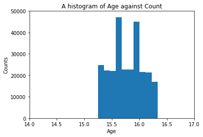

```python
# Plotting a histogram of age against count
display_histogram(df_pisa.AGE,'A histogram of Age against Count', 'Age','Counts')
binsize = 0.08
bins = np.arange(0, df_pisa['AGE'].max()+binsize, binsize)
plt.xlim(14,17)
plt.ylim(0,50000)
```

#### Question 2: What is the average Math Plausible Value Mean of the students?

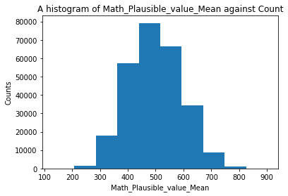

```python
# Plotting a histogram of Math Plausible Value Mean against count
display_histogram(df_pisa.Math_Plausible_value_Mean,'A histogram of Math_Plausible_value_Mean against Count', 'Math_Plausible_value_Mean','Counts')
binsize = 50
bins = np.arange(0, df_pisa['Math_Plausible_value_Mean'].max()+binsize, binsize)
plt.figure(figsize=[8, 5])
```

#### Question 3: What is the average Read Plausible Value Mean of the students?

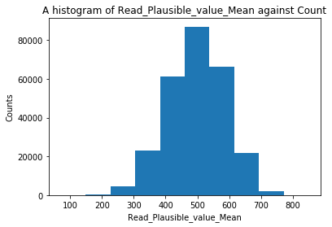

```python
# Plotting a histogram of Read Plausible Value Mean against count
display_histogram(df_pisa.Read_Plausible_value_Mean,'A histogram of Read_Plausible_value_Mean against Count', 'Read_Plausible_value_Mean','Counts')
binsize = 1
bins = np.arange(0, df_pisa['Read_Plausible_value_Mean'].max()+binsize, binsize)
plt.figure(figsize=[8, 5])
```

#### Observation

- The above histogram is *Unimodal*
- Most of the students score betweeen *400 and 600* with very few scoring just slightly below *200* and below *800*

#### Question 4: What is the average Science Plausible Value Mean of the students?

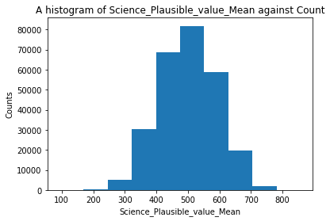

```python
# Plotting a histogram of Science Plausible Value Mean against count
display_histogram(df_pisa.Science_Plausible_value_Mean,'A histogram of Science_Plausible_value_Mean against Count', 'Science_Plausible_value_Mean','Counts')
binsize = 100
bins = np.arange(0, df_pisa['Science_Plausible_value_Mean'].max()+binsize, binsize)
plt.figure(figsize=[8, 5])
```

#### Observation

- The above histogram is *Unimodal*
- Most of the students score betweeen *400 and 600* with very few scoring just slightly above *200* and below *800*

#### Question 5: Are there more Wealthy students?

```
(0, 2)
```

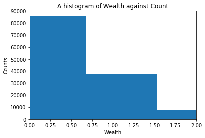

```python
# Plotting a histogram of Wealth against count
display_histogram(df_pisa.Wealth,'A histogram of Wealth against Count', 'Wealth','Counts')
binsize = 0.01
bins = np.arange(0, df_pisa['Math_Plausible_value_Mean'].max()+binsize, binsize)
plt.xlim(0,2)
```

#### Observation

- The above histogram s skewed to the right as expected.
- Most of the students lie in between the range of *0.0 to 0.5* with the smallest group of students lying between *1.5 and 1.75*

#### Question 6: Do most students have ICT Resources?

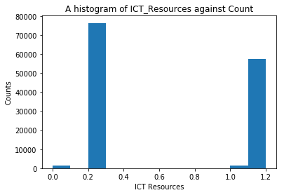

```python
# Plotting a histogram of ICT Resources against count
display_histogram(df_pisa.ICT_Resources,'A histogram of ICT_Resources against Count', 'ICT Resources','Counts')
binsize = 0.5
bins = np.arange(0, df_pisa['ICT_Resources'].max()+binsize, binsize)
plt.figure(figsize=[8, 5])
```

#### Observation

- Most of the students have very limited amount of ICT Resources, but also a good number have the highest amount of ICT Resources. Very few people have zero number of ICT Resources.

#### Question 6: Are the ICT Resources available at school?

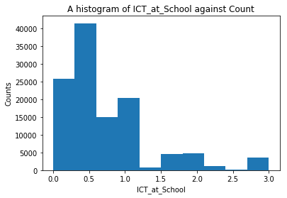

```python
# Plotting a histogram of ICT at School against count
display_histogram(df_pisa.ICT_at_School,'A histogram of ICT_at_School against Count', 'ICT_at_School','Counts')
binsize = 0.2
bins = np.arange(0, df_pisa['ICT_at_School'].max()+binsize, binsize)
plt.figure(figsize=[8, 5])
```

#### Observation

- The above histogram is skewed to the right.
- Most of the students are not offered ICT at School

Now with that in mind we need to look at how the *Qualitative Variables* behave. First, we create a *function* that will plot a bargraph and reduce repetition of code

```python
def display_bargraph(column,title,xlabel,ylabel):
    sb.color_palette()
    base_color=sb.color_palette()[0]
    sb.countplot(data=df_pisa,x=column,color=base_color);
    plt.title(title)
"'This function plots a bargraph'"
```

```
"'This function plots a bargraph'"
```

#### Question 1: Which gender are most students?

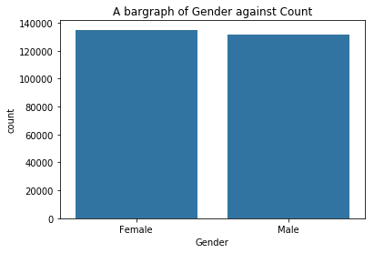

```python
# Plotting a bar graph of Gender against count
display_bargraph(df_pisa.Gender, 'A bargraph of Gender against Count', 'Gender','Counts')
```

#### Observation

- The ratio of male to female is almost *equal* with the students having a higher number of Females compared to male.

#### Question 2: Which Country do most of the students come from?

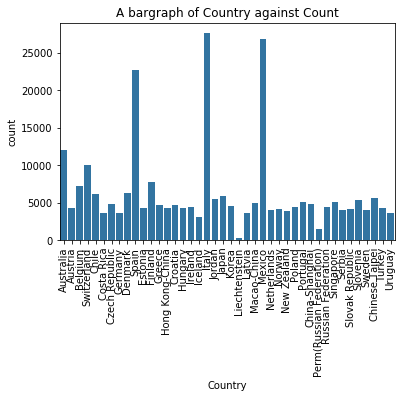

```python
# Plotting a bar graph of Country against count
display_bargraph(df_pisa.Country, 'A bargraph of Country against Count', 'Country','Counts')
plt.xticks(rotation=90);
```

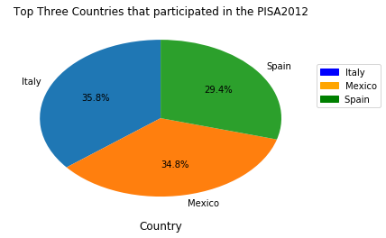

```python
# PLot a pie chart to indicate the top three countries that participated in the PISA Survey
country_count=df_pisa.Country.value_counts()[:3]
country_count.plot(kind='pie',title='Top Three Countries that participated in the PISA2012',startangle=90, autopct='%1.1f%%');
plt.xlabel('Country',fontsize=12)
plt.ylabel('',fontsize=12)
blue_patch = mpatches.Patch(color='blue', label='Italy')
orange_patch = mpatches.Patch(color='orange', label='Mexico')
green_patch = mpatches.Patch(color='green', label='Spain ')
plt.legend(handles=[blue_patch,orange_patch,green_patch],bbox_to_anchor=(1.0, 0.8));
```

#### Observation

- Most of the students come from *Italy*, followed by *Mexico* and *Spain* comes third.
- The least country from which this students come from is *Liechtenstein*

#### Question 3: Do most students have there mothers present?

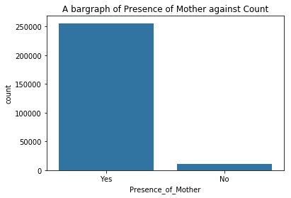

```python
# Plotting a bar graph of Presence of Mother against count
display_bargraph(df_pisa.Presence_of_Mother, 'A bargraph of Presence of Mother against Count', 'Presence_of_Mother','Counts')
```

#### Observation

- Yes, most students have there Mothers present compared to those that dont.

#### Question 3: Do most students have there Fathers present?

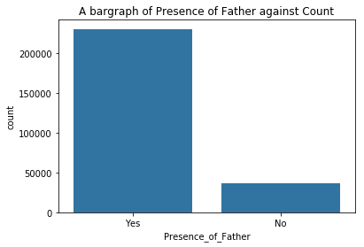

```python
# Plotting a bar graph of Presence of Father against count
display_bargraph(df_pisa.Presence_of_Father, 'A bargraph of Presence of Father against Count', 'Presence_of_Father','Counts')
```

#### Observation

- Also most students have there Fathers present compared to those that dont.

#### Question 4: Do most students Possess Computer?

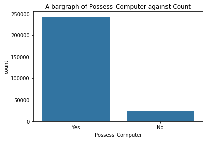

```python
display_bargraph(df_pisa.Possess_Computer, 'A bargraph of Possess_Computer against Count', 'Possess Computer','Counts')
```

#### Observation

- Most students possess Computers.

## Bivariate Exploration

In this section, we investigate relationships between pairs of variables in the *pisa2012* data.

As usual, we create a function that will plot a scatterplot and minimize on code repetition.

```python
def display_scatterplot(x,y,title,xlabel,ylabel):
    sb.regplot(df_pisa[x],df_pisa[y])
    plt.title(title)
    plt.ylabel(ylabel)
    plt.xlabel(xlabel)

"'This Function plots a scatter plot'"
```

```
"'This Function plots a scatter plot'"
```

#### Question 1: What is the relationship between the ICT at School and the three Plausible Value Means?

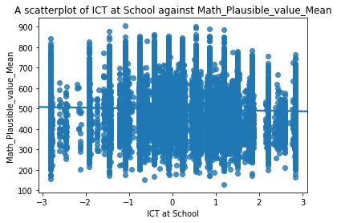

```python
# Plotting a scatter plot of ICT at School against Math Plausible Value Mean
display_scatterplot('ICT_at_School','Math_Plausible_value_Mean','A scatterplot of ICT at School against Math_Plausible_value_Mean','ICT at School','Math_Plausible_value_Mean')
```

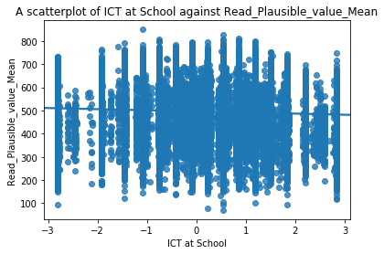

```python
# Plotting a scatter plot of ICT at School against Read Plausible Value Mean
display_scatterplot('ICT_at_School','Read_Plausible_value_Mean','A scatterplot of ICT at School against Read_Plausible_value_Mean','ICT at School','Read_Plausible_value_Mean')
```

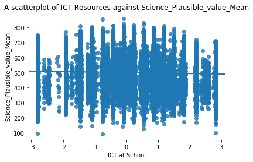

```python
# Plotting a scatter plot of ICT at School against Science Plausible Value Mean
display_scatterplot('ICT_at_School','Science_Plausible_value_Mean','A scatterplot of ICT Resources against Science_Plausible_value_Mean','ICT at School','Science_Plausible_value_Mean')
```

#### Observation

- There is a *low negative correlation* between *ICT at School* and *Math Palusible Value Mean* at the *500* mark
- There is a *low negative correlation* between *ICT at School* and *Read Palusible Value Mean* slightly above the *500* mark. This is the same for the *Science Plausible Value Mean*

#### Question 2: What is the relationship between the ICT Resources and the three Plausible Value Means?

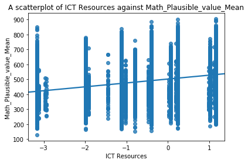

```python
# Plotting a scatter plot of ICT Resources against Math Plausible Value Mean
display_scatterplot('ICT_Resources','Math_Plausible_value_Mean','A scatterplot of ICT Resources against Math_Plausible_value_Mean','ICT Resources','Math_Plausible_value_Mean')
```

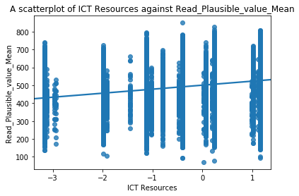

```python
# Plotting a scatter plot of ICT Resources against Read Plausible Value Mean
display_scatterplot('ICT_Resources','Read_Plausible_value_Mean','A scatterplot of ICT Resources against Read_Plausible_value_Mean','ICT Resources','Read_Plausible_value_Mean')
```

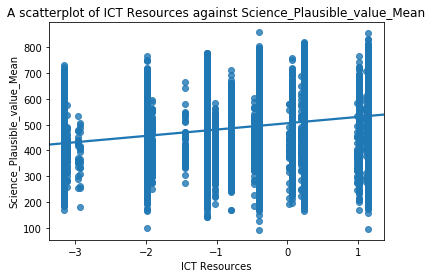

```python
# Plotting a scatter plot of ICT Resources against Science Plausible Value Mean
display_scatterplot('ICT_Resources','Science_Plausible_value_Mean','A scatterplot of ICT Resources against Science_Plausible_value_Mean','ICT Resources','Science_Plausible_value_Mean')
```

#### Observation

- Interestingly, there is a *low positive correlation* between *ICT Resources* and the *three Palusible Value Means*
- The *Line of Regresson* lies between **400 and 550

#### Question 3: What is the relationship between the Wealth and three Plausible Value Means?

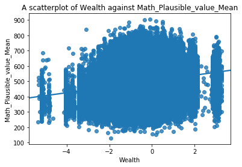

```python
# Plotting a scatter plot of Wealth against Math Plausible Value Mean
display_scatterplot('Wealth','Math_Plausible_value_Mean','A scatterplot of Wealth against Math_Plausible_value_Mean','Wealth','Math_Plausible_value_Mean')
```

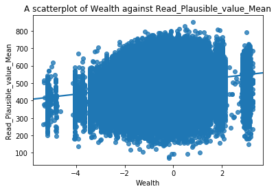

```python
# Plotting a scatter plot of Wealth against Read Plausible Value Mean
display_scatterplot('Wealth','Read_Plausible_value_Mean','A scatterplot of Wealth against Read_Plausible_value_Mean','Wealth','Read_Plausible_value_Mean')
```

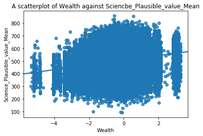

```python
# Plotting a scatter plot of Wealth against Science Plausible Value Mean
display_scatterplot('Wealth','Science_Plausible_value_Mean','A scatterplot of Wealth against Sciencbe_Plausible_value_Mean','Wealth','Science_Plausible_value_Mean')
```

#### Observation

- For the relationship between *Wealth* and the *three Plausible Maen Value* there is a *low positive correlation* between the two variables.
- The Line of Regression is steeper compared to the graphs in relation to ICT Resources. I lies between *400 and 600*

Now, to check the realtionship between *qualitative variable and quantitative variable*. First and foremost we create a fuction to plot a violin plot to avoid repeation of code.

```python
def display_violinplot(x,y,title):
    base_color=sb.color_palette()[0]
    sb.violinplot(data=df_pisa,x=x,y=y,color=base_color)
    plt.title(title)
"'This function plot a violin plot'"
```

```
"'This function plot a violin plot'"
```

#### Question 1: What is the relationship between the Wealth and Gender?

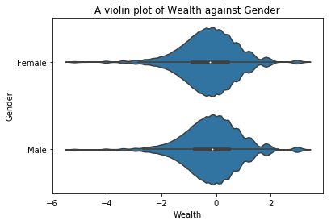

```python
# Plotting a violin plot of Wealth against Gender
display_violinplot('Wealth','Gender', 'A violin plot of Wealth against Gender')
```

#### Observation

Looking at the relationship between Wealth and Gender, the Violin plots are quite similar. For both Male and Female more score points are found the point when wealth is *0*(zero)

#### Question 2: What is the relationship between the three Plausible Value Means and Gender?

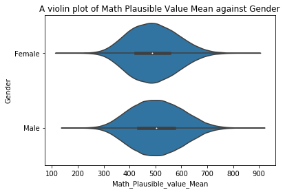

```python
# Plotting a violin plot of Math_Plausible_value_Mean against Gender
display_violinplot('Math_Plausible_value_Mean','Gender','A violin plot of Math Plausible Value Mean against Gender')
```

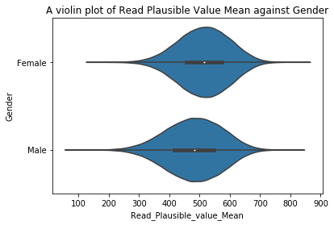

```python
# Plotting a violin plot of Read_Plausible_value_Mean against Gender
display_violinplot('Read_Plausible_value_Mean','Gender','A violin plot of Read Plausible Value Mean against Gender')
```

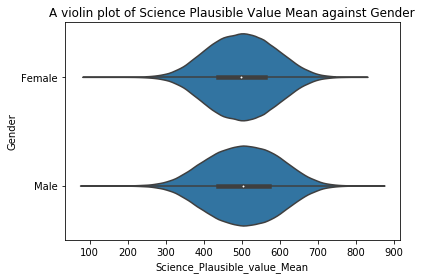

```python
# Plotting a violin plot of Science_Plausible_value_Mean against Gender
display_violinplot('Science_Plausible_value_Mean','Gender','A violin plot of Science Plausible Value Mean against Gender')
```

#### Observation

- For all the three Plausible Value means, Females tend to have more score points compared to Males at the *500 mark*

Finally, finding the relationship between two qualitative variables using *clustered bar graph*. First we ate a function in that accord.

```python
def display_clusterplot(x,hue,title,legend_title):
    sb.countplot(data=df_pisa,x=x,hue=hue)
    plt.legend(loc='best',bbox_to_anchor=(1.5, 1.0),title=legend_title);
    plt.title(title)

"'This function plots a clustered bar graph.'"
```

```
"'This function plots a clustered bar graph.'"
```

#### Question 1: What is the relationship between Gender and Number of Computers?

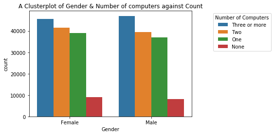

```python
# Plotting a Clusterplot plot of Gender & Number of Computers against count
display_clusterplot('Gender','Number_of_Computers', 'A Clusterplot of Gender & Number of computers against Count', 'Number of Computers')
```

#### Observation

- Male students who own three or more computers are more compared to the female students.
- However,female students who have one or two computers are more compared to the female students.
- There are more Female students who dont own a computer computer compared to the male students

#### Question 2: What is the relationship between Gender and Presence of Father?

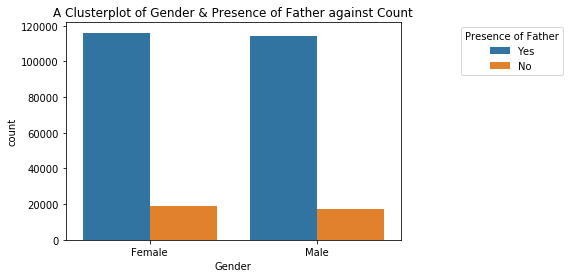

```python
# Plotting a Clusterplot plot of Gender & Presence of Father against count
display_clusterplot('Gender','Presence_of_Father', 'A Clusterplot of Gender & Presence of Father against Count','Presence of Father')
```

#### Observation

- Most of the students, both male and female students have a present father.
- Female students tend to have more absent fathers compared to the the male students

#### Question 3: What is the relationship between Presence of Father and Presence of Mother?

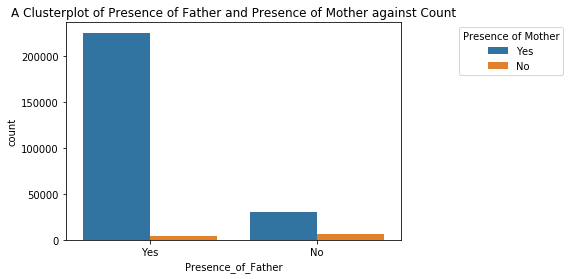

```python
# Plotting a Clusterplot plot of Presence of Father & Presence of Mother against count
display_clusterplot('Presence_of_Father','Presence_of_Mother', 'A Clusterplot of Presence of Father and Presence of Mother against Count','Presence of Mother')
```

#### Observation

- Most students have both present mother and father.
- The number of students who have no present mother is slower compared to those students who dont have both present father and present mother.

## Multivariate Exploration

Finally, we create plots of three or more variables to investigate your data even further. For this case I investigated the relationship between the three *Plausible Value Means*, to see how they relate to one another and how ICT Resources and Wealth affect them

```python
def display_colorscatter(x,y,c,label,xlabel,ylabel,title):
    plt.figure(figsize=[8,6])
    plt.scatter(data=df_pisa,x=x,y=y,c=c)
    plt.colorbar(label=label)
    plt.xlabel(xlabel)
    plt.ylabel(ylabel)
    plt.title(title)

"'This function plots a coloured scatter plot'"
```

```
"'This function plots a coloured scatter plot'"
```

#### Question 1: What is the relationship between the Plausible Value Means, wealth and ICT Resources?

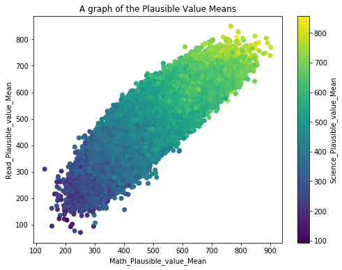

```python
# Plotting a Color_Scatterplot plot of Plausible Value Means
display_colorscatter('Math_Plausible_value_Mean','Read_Plausible_value_Mean','Science_Plausible_value_Mean','Science_Plausible_value_Mean','Math_Plausible_value_Mean','Read_Plausible_value_Mean','A graph of the Plausible Value Means')
```

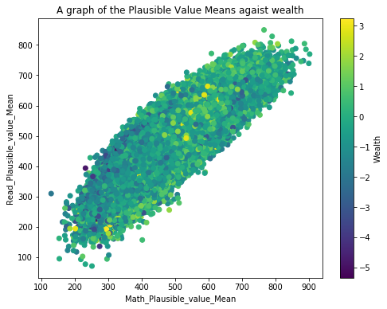

```python
# Plotting a Color_Scatterplot plot of Plausible Value Means abd Wealth
display_colorscatter('Math_Plausible_value_Mean','Read_Plausible_value_Mean','Wealth','Wealth','Math_Plausible_value_Mean','Read_Plausible_value_Mean','A graph of the Plausible Value Means agaist wealth')
```

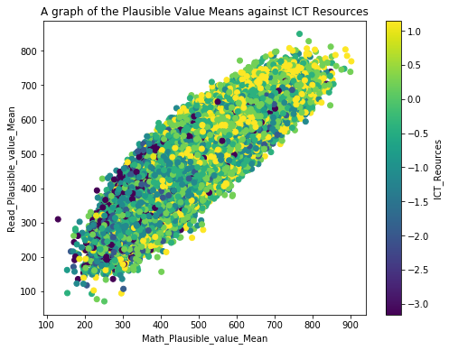

```python
# Plotting a Color_Scatterplot plot of Plausible Value Means abd ICT Resources
display_colorscatter('Math_Plausible_value_Mean','Read_Plausible_value_Mean','ICT_Resources','ICT_Reources','Math_Plausible_value_Mean','Read_Plausible_value_Mean','A graph of the Plausible Value Means against ICT Resources')
```

#### Observation

- Students who have a low Plausible Value mean in both Math and Read also have a low Science Plausible Value Mean
- There are two bright points in the graph;
  1. Have a low Plasible Value Mean of both Math and Read
  2. Have an average Plausible Value Mean of both math and Read
- Seems most of the students with ICT Resources tend to have a higher Plausible Value Mean of both Math and Read compared those who dont have the ICT Resources.

## Conclusions

#### Bivariate Exploration Observations

1. There is a *low negative correlation* between *ICT at School* and *Math Palusible Value Mean* at the *500* mark
2. There is a *low negative correlation* between *ICT at School* and *Read Palusible Value Mean* slightly above the *500* mark. This is the same for the *Science Plausible Value Mean*
3. Interestingly, there is a *low positive correlation* between *ICT Resources* and the *three Palusible Value Means*. The *Line of Regresson* lies between **400 and 550
4. For the relationship between *Wealth* and the *three Plausible Maen Value* there is a *low positive correlation* between the two variables.The Line of Regression is steeper compared to the graphs in relation to ICT Resources. It lies between *400 and 600*
5. Looking at the relationship between Wealth and Gender, the Violin plots are quite similar. For both Male and Female most score points are found the point when wealth is *0*(zero)
6. For all the three Plausible Value means, Females tend to have more score points compared to Males at the *500 mark*
7. Male students who own three or more computers are more compared to the female students.However,female students who have one or two computers are more compared to the female students.There are more Female students who dont own a computer computer compared to the male students
8. Most of the students, both male and female students have a present father. Female students tend to have more absent fathers compared to the the male students
9. Most students have both present mother and father. The number of students who have no present mother is slower compared to those students who dont have both present father and present mother

#### Multivariate Exploration Observations

1. Students who have a low Plausible Value mean in both Math and Read also have a low Science Plausible Value Mean
2. There are two bright points in the graph;
   - Have a low Plasible Value Mean of both Math and Read
   - Have an average Plausible Value Mean of both math and Read
3. Seems most of the students with ICT Resources tend to have a higher Plausible Value Mean of both Math and Read compared those who dont have the ICT Resources.

### References

- Kaggle - https://www.kaggle.com/code/szelee/how-to-import-a-csv-file-of-55-million-rows
- Geek for Geeks - https://www.geeksforgeeks.org/bin-size-in-matplotlib-histogram/ , https://www.geeksforgeeks.org/bin-size-in-matplotlib-histogram/
- Stack Over Flow - https://stackoverflow.com/questions/43005462/pandas-bar-plot-with-binned-range